# UNIT12A：類別模型的準確性指標

模型的準確性

第 5 組

2019-12-02 19:09:01

**案例：糖尿病患醫療品質**

```r
pacman::p_load(caTools, ggplot2, dplyr)
D = read.csv("data/quality.csv")  # Read in dataset
set.seed(88)
split = sample.split(D$PoorCare, SplitRatio = 0.75)  # split vector
TR = subset(D, split == TRUE)
TS = subset(D, split == FALSE)
glm1 = glm(PoorCare ~ OfficeVisits + Narcotics, TR, family=binomial)
summary(glm1)
```

[output not shown]

### 【A】傳統準確性指標

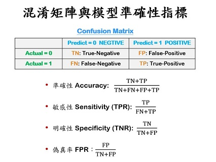

Fig 12.1 - 混淆矩陣與模型準確性指標

##### Training Data

**預測機率 Predicted Probability (Training)**

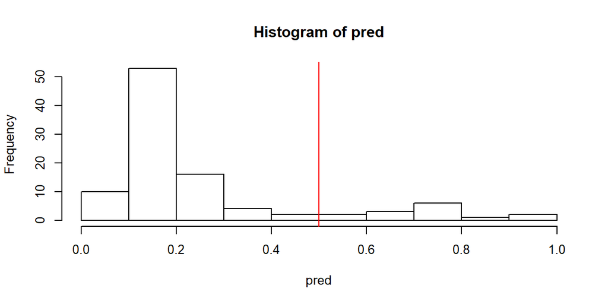

```r
par(cex=0.8)
pred = predict(glm1, type="response")
hist(pred)
abline(v=0.5, col='red')
```

**混淆矩陣 Confusion Matrix (Training)**

```r
cmx = table(Acture=TR$PoorCare, Predict=pred > 0.5)
cmx
```

```
      Predict
Acture FALSE TRUE
     0    70    4
     1    15   10
```

**模型準確性指標 Accuracy Metrices (Training)**

```r
Accuracy = function(x, k=3) c(
  accuracy = sum(diag(x))/sum(x),
  sensitivity = as.numeric(x[2,2]/rowSums(x)[2]),
  specificity = as.numeric(x[1,1]/rowSums(x)[1])
  ) %>% round(k)
Accuracy(cmx)#, k=5) # 看小數點
```

```
   accuracy sensitivity specificity
      0.808       0.400       0.946
```

##### Testing Data

**預測機率 Predicted Probability (Testing)**

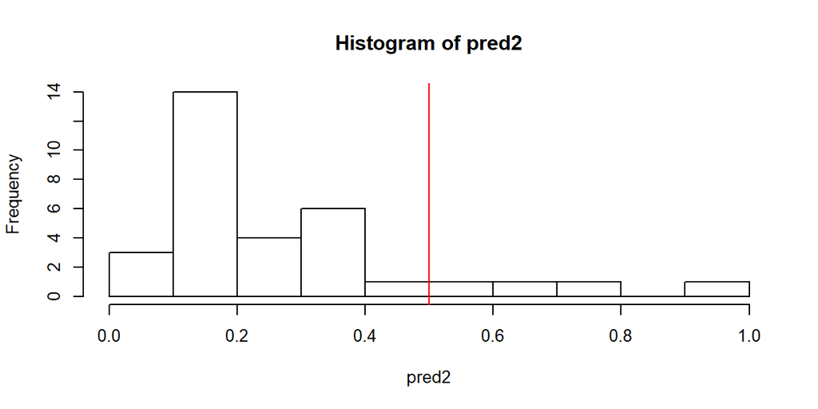

```r
par(cex=0.8)
pred2 = predict(glm1, newdata=TS, type="response")
hist(pred2, 10)
abline(v=0.5, col='red')
```

**混淆矩陣 Confusion Matrix (Testing)**

```r
cmx2 = table(Acture=TS$PoorCare, Predict=pred2 > 0.5)
cmx2
```

```
      Predict
Acture FALSE TRUE
     0    23    1
     1     5    3
```

**模型準確性指標 Accuracy Matrices (Testing)**

```r
# Test 和 Train 測出來差不多 代表沒有過度適配
sapply(list(Train=cmx, Test=cmx2), Accuracy)
```

```
            Train  Test
accuracy    0.808 0.812
sensitivity 0.400 0.375
specificity 0.946 0.958
```

### 【B】預測機率分佈、臨界機率、混淆矩陣

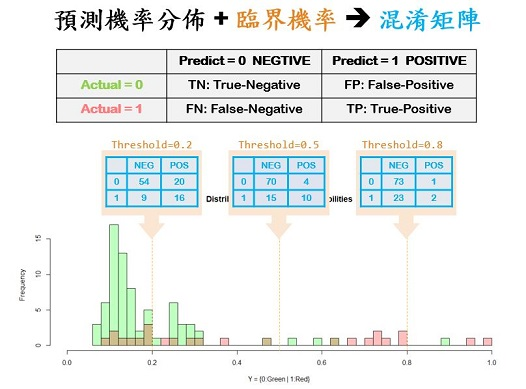

Fig 12.2 - 預測機率分佈、臨界機率、混淆矩陣

**預測機率分佈 (DPP) - Distribution of Predicted Probability (Train)**

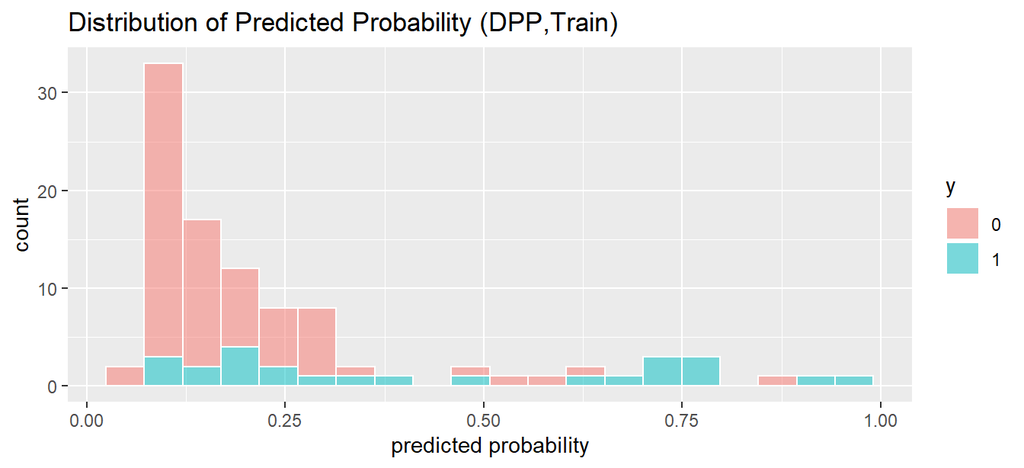

```r
data.frame(y=factor(TR$PoorCare), pred=pred) %>%
  ggplot(aes(x=pred, fill=y)) +
  geom_histogram(bins=20, col='white', position="stack", alpha=0.5) +
  ggtitle("Distribution of Predicted Probability (DPP,Train)") +
  xlab("predicted probability")
```

**預測機率分佈 (DPP) - Distribution of Predicted Probability (Test)**

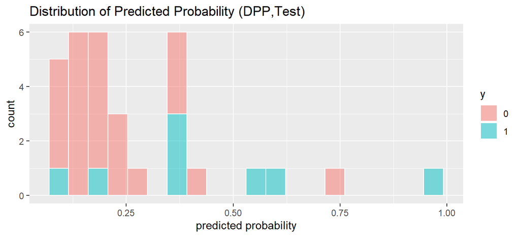

```r
data.frame(y=factor(TS$PoorCare), pred=pred2) %>%
  ggplot(aes(x=pred, fill=y)) +
  geom_histogram(bins=20, col='white', position="stack", alpha=0.5) +
  ggtitle("Distribution of Predicted Probability (DPP,Test)") +
  xlab("predicted probability")
```

### 【C】作業曲線(ROC)與辨識率(AUC)

**ROC - Receiver Operation Curve**

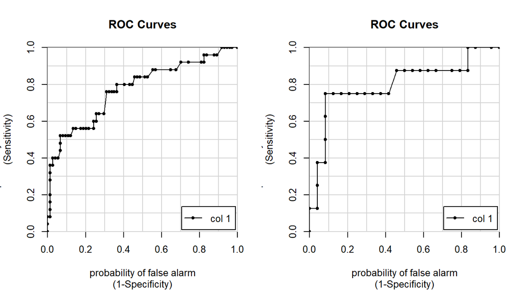

```r
par(mfrow=c(1,2), cex=0.8)
trAUC = colAUC(pred, y=TR$PoorCare, plotROC=T)
tsAUC = colAUC(pred2, y=TS$PoorCare, plotROC=T)
```

**AUC - Area Under Curve**

```r
c(trAUC, tsAUC)
```

```
[1] 0.77459 0.79948
```

### 【D】小組作業

🗿 練習：  
使用`TR$MemberID`以外的所有欄位，建立一個邏輯式回歸模型來預測`PoorCare`，並：  
【A】 分別畫出`Training`和`Testing`的`DPP`  
【B】 分別畫出`Training`和`Testing`的`ROC`  
【C】 分別算出`Training`和`Testing`的`ACC`、`SENS`和`SPEC`  
【D】 分別算出`Training`和`Testing`的`AUC`  
【E】 跟用兩個預測變數的模型相比，這一個模型有比較準嗎？  
【F】 為什麼它比較準(或比較不準)呢？

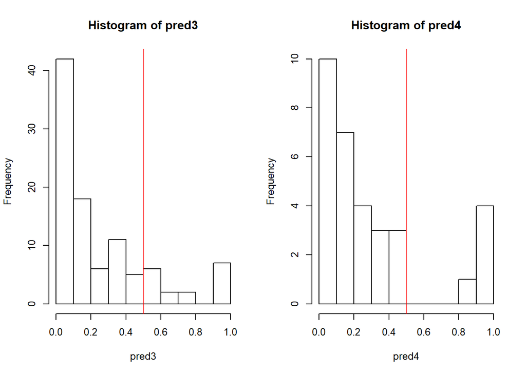

```r
#建模型(Training)
glm3 = glm(PoorCare ~ .,TR[,-1], family=binomial)

#預測機率
par(cex=0.8)
pred3 = predict(glm3, type="response")
hist(pred3)
abline(v=0.5, col='red')


par(cex=0.8)
pred4 = predict(glm3, newdata=TS, type="response")
hist(pred4,10)
abline(v=0.5, col='red')
```

```r
#混淆矩陣
cmx3 = table(Acture=TR$PoorCare, Predict=pred3 > 0.5)
cmx3
```

```
      Predict
Acture FALSE TRUE
     0    68    6
     1    14   11
```

```r
cmx4 = table(Acture=TS$PoorCare, Predict=pred4 > 0.5)
cmx4
```

```
      Predict
Acture FALSE TRUE
     0    23    1
     1     4    4
```

> 【A】 分別畫出`Training`和`Testing`的`DPP`

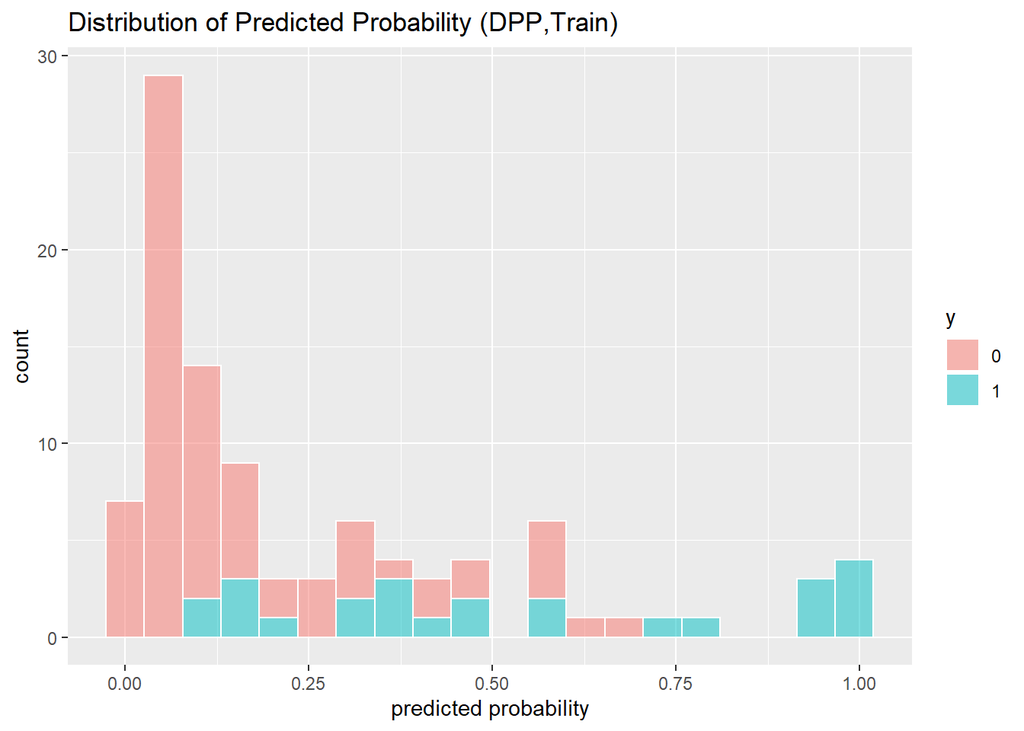

```r
#預測機率分佈(DPP)
data.frame(y=factor(TR$PoorCare), pred3=pred3) %>%
  ggplot(aes(x=pred3, fill=y)) +
  geom_histogram(bins=20, col='white', position="stack", alpha=0.5) +
  ggtitle("Distribution of Predicted Probability (DPP,Train)") +
  xlab("predicted probability")
```

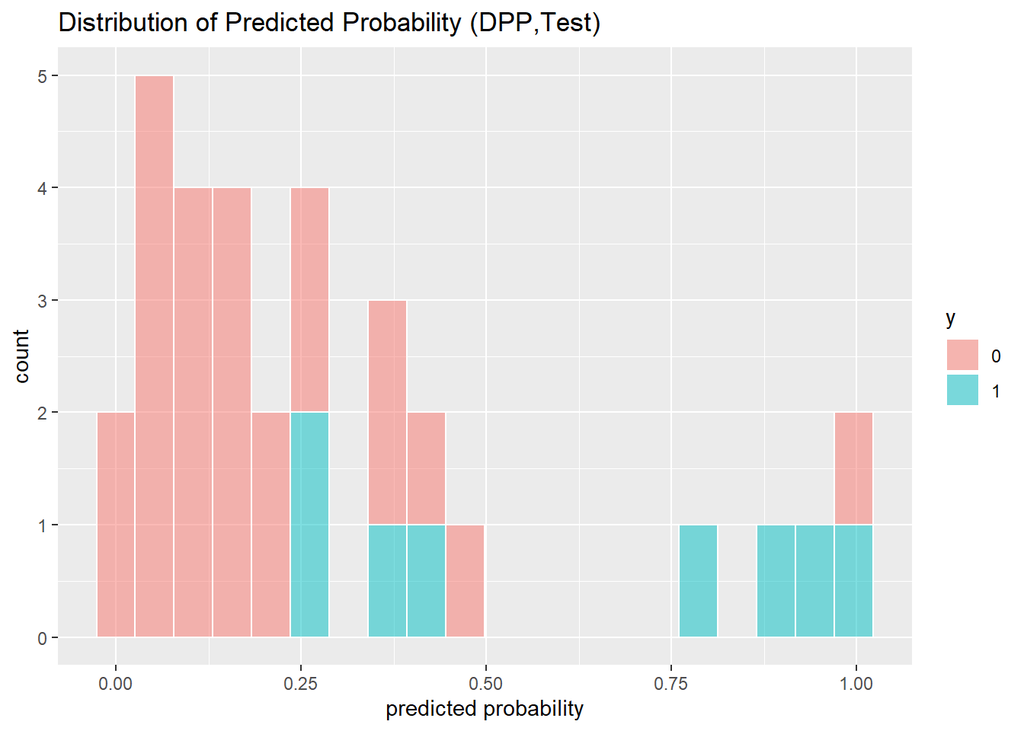

```r
data.frame(y=factor(TS$PoorCare), pred4=pred4) %>%
  ggplot(aes(x=pred4, fill=y)) +
  geom_histogram(bins=20, col='white', position="stack", alpha=0.5) +
  ggtitle("Distribution of Predicted Probability (DPP,Test)") +
  xlab("predicted probability")
```

> 【B】 分別畫出`Training`和`Testing`的`ROC`

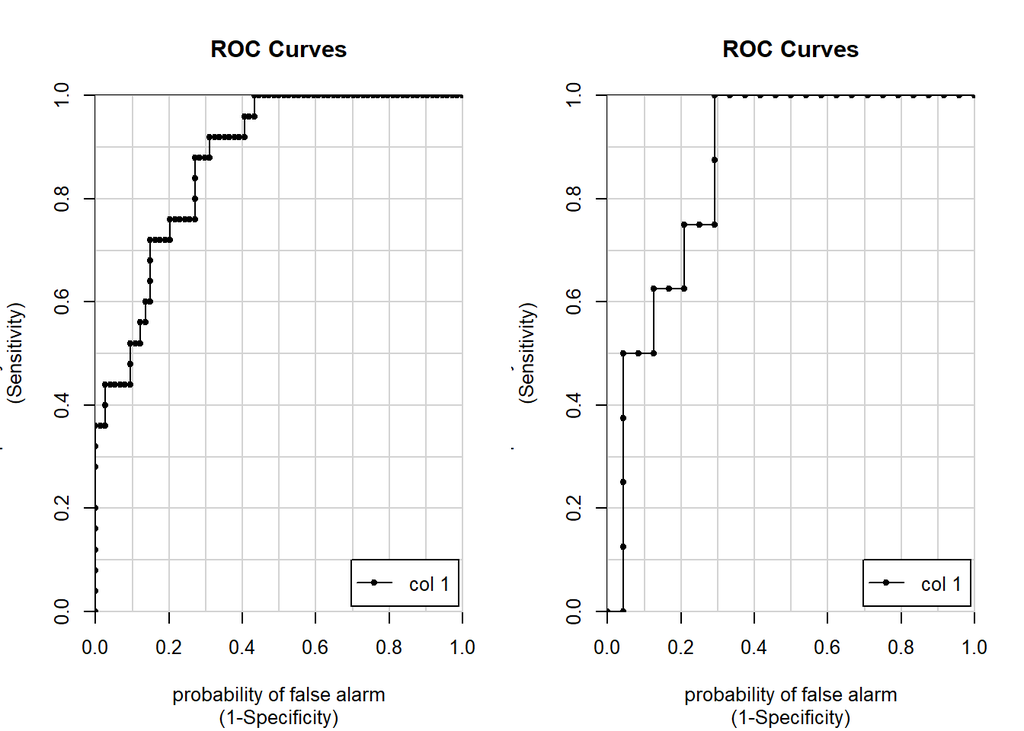

```r
#作業曲線(ROC)
par(mfrow=c(1,2), cex=0.8)
trAUC = colAUC(pred3, y=TR$PoorCare, plotROC=T)
tsAUC = colAUC(pred4, y=TS$PoorCare, plotROC=T)
```

> 【C】 分別算出`Training`和`Testing`的`ACC`、`SENS`和`SPEC`

```r
#模型準確性指標
sapply(list(Train=cmx3, Test=cmx4), Accuracy)
```

```
            Train  Test
accuracy    0.798 0.844
sensitivity 0.440 0.500
specificity 0.919 0.958
```

> 【D】 分別算出`Training`和`Testing`的`AUC`

```r
#辨識率(AUC)
c(trAUC, tsAUC)
```

```
[1] 0.87568 0.86458
```

> 【E】 跟用兩個預測變數的模型相比，這一個模型有比較準嗎？  
> 【F】 為什麼它比較準(或比較不準)呢

```r
# A1: 根據兩個模型的AUC數值來看
# 可以發現多個預測變數模型的trAUC和tsAUC都比兩個預測變數模型的大，所以推論多個預測變數的模型比較準
# A2: 因為新的模型考慮了更多預測變數
```